# SHAP_value - binary class

```python
from sklearn import datasets
import pandas as pd
from sklearn.model_selection import train_test_split
from sklearn.ensemble import RandomForestClassifier #랜덤 포레스트
```

```python
iris = datasets.load_iris() #iris 데이터 불러오기.

iris.keys()
#dict_keys(['data', 'target', 'target_names', 'DESCR', 'feature_names', 'filename'])
```

```
dict_keys(['data', 'target', 'target_names', 'DESCR', 'feature_names'])
```

```python
#X와 Y 데이터 설정
X = pd.DataFrame(iris.data, columns=iris.feature_names) #X
Y = pd.DataFrame(iris.target) #setosa', 'versicolor', 'virginica'

#setosa 이면, 1  else 0 로 세토사를 찾아 봅시다.
setosa_idx = Y == 0
not_setosa_idx = Y != 0

#Y에는 setosa면 1, 아니면 0 이 들어 있음.
Y[setosa_idx] = 1
Y[not_setosa_idx] = 0
```

```python
train_X, val_X, train_y, val_y = train_test_split(X, Y, test_size=0.01 ,random_state=1)
# 2개의 데이터를 제외하고 전부 train에 넣는다.

my_model = RandomForestClassifier(random_state=0).fit(train_X, train_y)
```

```python
pd.concat([val_X, val_y], axis=1)
```

|  | sepal length (cm) | sepal width (cm) | petal length (cm) | petal width (cm) | 0 |
| --- | --- | --- | --- | --- | --- |
| 14 | 5.8 | 4.0 | 1.2 | 0.2 | 1 |
| 98 | 5.1 | 2.5 | 3.0 | 1.1 | 0 |

```python
import shap #shap값을 보기 위해.

#첫 데이터는 setosa인데 변수들이 어떤 협의에 걸쳐 setosa로 분류 되었는지 확인.
row_to_show = 0


data_for_prediction = val_X.iloc[row_to_show]  # use 1 row of data here. Could use multiple rows if desired
data_for_prediction_array = data_for_prediction.values.reshape(1, -1)

# SHAP value 계산을 위해 Tree전용 으로 설정한다.
explainer = shap.TreeExplainer(my_model)

# Shap value 계산
shap_values = explainer.shap_values(data_for_prediction)

#내 모델의 아웃 풋
my_model.predict_proba(data_for_prediction_array)
#[[0, 1]]
#--> [[ setosa가 아닌 확률은 0% , setosa일 확률을 100%로 예측 ]]
```

```
array([[0., 1.]])
```

```python
shap_values
```

[array([ 0.03133858, -0.00101351, -0.13648649, -0.57086561]), array([-0.03133858, 0.00101351, 0.13648649, 0.57086561])]

```
각 클래스 대해 각각 Shap value를 결과로 반환합니다.

0(not setosa) 에 대한 SHAP : array([ 0.03133858, -0.00101351, -0.13648649, -0.57086561]),

1(setosa) 에 대한 SHAP : array([-0.03133858, 0.00101351, 0.13648649, 0.57086561])

이후 사용하는 SHAP value는 흔히 예측을 논할 때 사용하는 1(setosa)에 대한 SHAP 값만을 사용합니다.
결과를 시각화 하면 왜 그렇게 하는지 이해가 될 것 같습니다.
```

또한, 코드 중간에 있는 shap.TreeExplainer(my_model) 의 경우, Tree 모델이 적합한 함수입니다. 딥러닝 모델이나 다른 모델의 경우에는 아래 함수를 사용합니다.

- shap.DeepExplainer() works with Deep Learning models.
- shap.KernelExplainer() works with all models, though it is slower than other Explainers and it offers an approximation rather than exact Shap values.

```python
#모델의 Base 기댓값. 여기서 부터
#각 변수의 역할을 살펴 볼 수 있다.
explainer.expected_value[1]
```

```
0.32297297297297295
```

```python
shap.initjs()
shap.force_plot(explainer.expected_value[1], shap_values[1], data_for_prediction)
```

14번 데이터는(0번재 val_X) 다음과 같은 특징을 가지고 있습니다.  
sepal length (cm) 5.8  
sepal width (cm) 4.0  
petal length (cm) 1.2  
petal width (cm) 0.2

모델의 Base = 0.323 에서 각각의 feature들이 어떤 작용을 했는지 살펴 보겠습니다.

1) Sepal.length = 5.8 의 역할은 **SHAP= -0.03** 이므로, Setosa라고 예측하는데 negative한 영향을 주었습니다.  
2) Sepal.width = 4.0 의 역할은 SHAP= 0.001 로, Setosa라고 예측하는데 positive한 영향을 주었습니다.(아주 조금)  
3) Petal.length = 1.2 의 역할은 SHAP= 0.136 로, Setosa라고 예측하는데 positive한 영향을 주었습니다.  
4) Petal.width = 0.2 의 역할은 **SHAP= 0.570** 로, Setosa라고 예측하는데 positive한 영향을 주었습니다.(매우 많이)

SHAP value의 합은 0.677 이므로 최종 예측 값은  
Base (0.323) + SHAP (0.677) = 1 로 예측합니다.

```python
#두 번째 데이터는 not setosa인데 변수들이 어떤 협의에 걸쳐 not setosa로 분류 되었는지 확인.
row_to_show = 1

data_for_prediction = val_X.iloc[row_to_show]
data_for_prediction_array = data_for_prediction.values.reshape(1, -1)

# SHAP value 계산을 위해 Tree전용 으로 설정한다.
explainer = shap.TreeExplainer(my_model)

# Shap value 계산
shap_values = explainer.shap_values(data_for_prediction)

#내 모델의 아웃 풋
my_model.predict_proba(data_for_prediction_array)
```

```
array([[1., 0.]])
```

```python
shap_values
```

[array([-0.05676834, 0.06611969, 0.06351351, 0.25010811]), array([ 0.05676834, -0.06611969, -0.06351351, -0.25010811])]

```python
shap.initjs()
shap.force_plot(explainer.expected_value[1], shap_values[1], data_for_prediction)
```

98번 데이터(1번째 val_X)는 다음과 같은 특징을 가지고 있습니다.  
sepal length (cm) 5.1  
sepal width (cm) 2.5  
petal length (cm) 3.0  
petal width (cm) 1.1

모델의 Base = 0.323 에서 각각의 feature들이 어떤 작용을 했는지 살펴 보겠습니다.

1) Sepal.length = 5.1 의 역할은 **SHAP= 0.056** 이므로, Setosa라고 예측하는데 positive한 영향을 주었습니다.  
2) Sepal.width = 2.5 의 역할은 SHAP= -0.06 로, Setosa라고 예측하는데 negative한 영향을 주었습니다.  
3) Petal.length = 3.0 의 역할은 SHAP= -0.06 로, Setosa라고 예측하는데 negative한 영향을 주었습니다.  
4) Petal.width = 1.1 의 역할은 **SHAP= -0.25** 로, Setosa라고 예측하는데 negative한 영향을 주었습니다.(매우 많이)

SHAP value의 합은 -0.323 이므로 최종 예측 값은  
Base (0.323) + SHAP (-0.323) = 0 로 예측합니다.

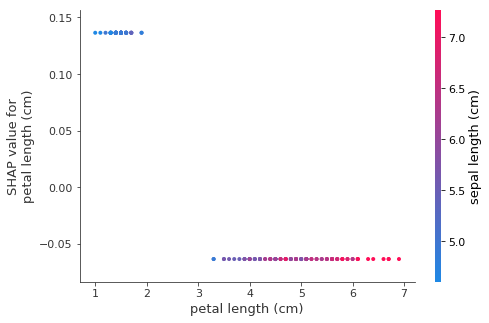

```python
shap_values = explainer.shap_values(train_X)
shap.dependence_plot("petal length (cm)", shap_values[1], train_X, interaction_index='sepal length (cm)')
```

두 Length값이 주는 영향을 알아보기 위해 위 그림을 그렸습니다.

Sepal.length의 의 값은 커질수록 붉은 색으로 표시가 되었습니다. (오른쪽 막대 참조)  
Petal.length는 X축에 위치하며, SHAP value는 잘 구분 되어 나온 것을 확인 할 수 있습니다.

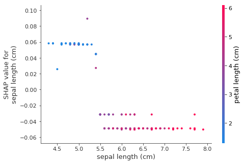

```python
shap.dependence_plot("sepal length (cm)", shap_values[1], train_X, interaction_index='petal length (cm)')
```

그림을 반대로 그릴 경우 마찬가지로 SHAP그림을 그릴 수 있으며, 붉은 점(Petal.length이 클수록)은 대체로 아랫부분에

파란점(Petal.length가 작을 수록)은 대체로 큰 SHAP값을 가지고 있습니다.

즉, 꽃받침과 꽃잎의 길이가 짧아야 지만 Setosa라고 판별하는데 긍정적인 영향을 미치고 있다는 점을 알 수 있습니다.

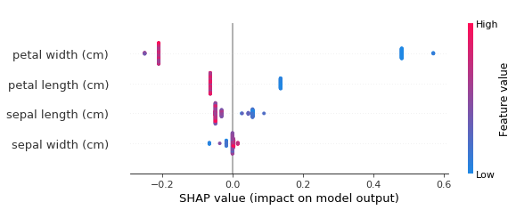

```python
shap.summary_plot(shap_values[1], train_X)
```

feature importance와 비슷하게 평균적인 SHAP value값을 반환할 수 있음.

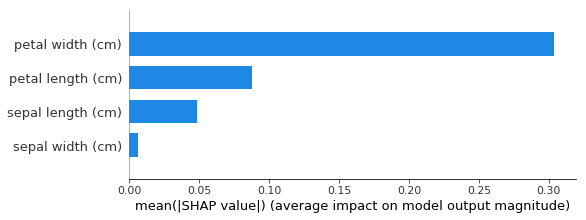

```python
shap.summary_plot(shap_values[1], train_X, plot_type="bar")
```

```python
# Calculate Shap values
shap_values = explainer.shap_values(train_X)

my_model.predict_proba(data_for_prediction_array)

shap.initjs()
shap.force_plot(explainer.expected_value[1], shap_values[1], train_X)
```

```python
shap_interaction_values  = shap.TreeExplainer(my_model).shap_interaction_values(train_X)
```

```python
shap_interaction_values[2][1]
```

[output not shown]

```python
shap.summary_plot(shap_interaction_values[2], train_X)
```

[output not shown]